# INLA replication

Adam Howes

Abstract

We demonstrate a step-by-step example of the INLA method implemented in R and TMB.

```r
knitr::opts_chunk$set(
  echo = TRUE,
  cache = TRUE,
  autodep = TRUE,
  cache.comments = FALSE
)

library(tidyverse)
library(TMB)
library(INLA)
library(rmarkdown)

midblue <- "#3D9BD0"
midgreen <- "#00855A"
midpink <- "#B3608E"
```

# Background

Consider a three-stage model
$$\begin{alignat}{2}
&\text{(Observations)} & y_i &\sim p(y_i \, | \,
x_i, \theta), \quad i \in \mathcal{I}, \\
&\text{(Latent field)} & x &\sim \mathcal{N}(x \, |
\,\mathbf{0}, \mathbf{Q}(\theta)^{-1}), \\
&\text{(Hyperparameters)} & \qquad \theta &\sim
p(\theta), \label{eq:hyper}
\end{alignat}$$
with posterior
$$\begin{equation}
p(x, \theta \, | \, y) \propto p(y, x, \theta) = p(y \, | \, x,
\theta) p(x \, | \, \theta) p(\theta).
\end{equation}$$

After writing the negative log-target in a C++ file `model.cpp` it can be compiled and loaded into R:

```r
compile("model.cpp")
dyn.load(dynlib("model"))
```

Let $f(x, \theta) \equiv - \log p(y, x, \theta)$ where $y$ is assumed to be fixed. This objective (`f$fn`) and its derivative (`f$gn`) can be created (sketch) in `TMB` using:

```r
f <- MakeADFun(data = dat, parameters = param, DLL = "model")
```

There are four stages to replicating the INLA method.

## Stage 1: get $\tilde p(\theta \, | \, y)$

Approximate the posterior marginal $p(\theta \, | \, y) \propto L(\theta)$ using the Laplace approximation $L(\theta) \approx L^\star(\theta)$:
$$\begin{equation}
\tilde p(\theta \, | \, y) \propto \frac{p(y \, | \, x, \theta) p(x \, |
\, \theta) p(\theta)}{\tilde p_G(x \, | \, \theta, y)} \Big\rvert_{x =
\mu^\star(\theta)} \equiv L^\star(\theta)
\end{equation}$$

Using `TMB` if we integrate out the latent field $x$ using the argument `random = "x"` in `MakeADFun` then the result is the negative log of the Laplace approximation to the marginal likelihood $h(\theta) \equiv - \log L^\star(\theta)$:

```r
h <- MakeADFun(data = dat, parameters = param, DLL = "model", random = "x")
```

Therefore, `exp(-h$fn(theta))` is proportional to $\tilde p(\theta \, | \, y)$:

## Stage 2: choose $\{\theta_k, \Delta_k\}_{k = 1}^K$

Integration points $\{\theta_k\}$ with weights $\sum_{k = 1}^K \Delta_k = 1$.

### Empirical Bayes

$K = 1$ with integration point $\text{argmin}_{\theta} (-\log L^\star_f(\theta))$. This can be found by minimising `h` using optimisers like `nlminb` or `optim`.

### INLA grid

The steps required are:

1. Locate the mode of $\log p(\theta \, | \, y)$ which is the same as $\text{argmin}_{\theta} (-\log L^\star_f(\theta))$ and can be calculated as above.
2. Calculate negative Hessian at the mode. The solution is likely to use some version of `h$env$spHess` although it’s not clear which one.
3. Test points against the $\delta_z$ condition

### Adaptive Gaussian Hermite quadrature

## Stage 3: get $\tilde p(x_i \, | \, \theta, y)$

### Gaussian

Obtain marginals of $\tilde p_G(x \, | \, \theta, y)$ from above.

### Laplace

Compute the Laplace approximation

## Stage 4: apply quadrature

$$\begin{equation}
\tilde p(x_i \, | \, y) =
\sum_{k = 1}^K \tilde p(x_i \, | \, \theta^{(k)}, y) \times \tilde
p(\theta^{(k)} \, | \, y) \times \Delta^{(k)}
\end{equation}$$

# Example 1: Blangiardo

Consider the following simple model for i.i.d. observations $y = (y_1, \ldots, y_n)$
$$\begin{align}
y_i \, | \, x, \theta &\sim \mathcal{N}(x, 1/\theta), \\
x &\sim \mathcal{N}(x_0 = -3, 1/\tau_0 = 4), \\
\theta &\sim \text{Gamma}(a = 1.6, b = 0.4).
\end{align}$$

We start by loading the data manually:

```r
y <- c(
  1.2697, 7.7637, 2.2532, 3.4557, 4.1776, 6.4320, -3.6623, 7.7567, 5.9032, 7.2671,
  -2.3447, 8.0160, 3.5013, 2.8495, 0.6467, 3.2371, 5.8573, -3.3749, 4.1507, 4.3092,
  11.7327, 2.6174, 9.4942, -2.7639, -1.5859, 3.6986, 2.4544, -0.3294, 0.2329, 5.2846
)

n <- length(y)
y_bar <- mean(y)
```

The observations (ordered by index, though this has no interpretation) and prior (mean shown as dashed line, which is significantly different to the data):

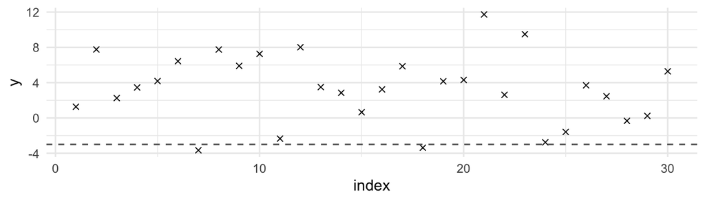

```r
data.frame(index = 1:30, y = y) %>%
  ggplot(aes(x = index, y = y)) +
  geom_point(shape = 4) +
  geom_hline(yintercept = -3, col = "#666666", lty = "dashed") +
  theme_minimal()
```

We use the following parameters of the prior distribution:

```r
x_0 <- -3
tau_0 <- 1/4
a <- 1.6
b <- 0.4
```

## Implementation using `R-INLA`

This model is simple to fit using the `R-INlA` software directly:

```r
formula <- y ~ 1
dat <- list(y = y)

theta_prior <- list(prec = list(prior = "loggamma", param = c(a, b)))

fit <- inla(
  formula,
  data = dat,
  control.family = list(hyper = theta_prior),
  control.fixed = list(mean.intercept = x_0, prec.intercept = tau_0)
)
```

## Implementation using R

The distribution $p(x \, | \, \theta, y)$ is exact:

```r
inner_loop <- function(theta) {
  tau_n <- n * theta + tau_0
  x_n <- (theta * n * y_bar + tau_0 * x_0) / tau_n
  return(list(x_n = x_n, tau_n = tau_n))
}
```

Functions with $\theta > 0$ constraint and on the $\log(\theta)$ scale to avoid this constraint:

```r
nl_full_conditional_x <- function(x, theta, log_input = FALSE) {
  if(log_input == TRUE) theta <- exp(theta) # Convert from log(theta) to theta
  par <- inner_loop(theta)
  return(-dnorm(x, par$x_n, sqrt(1 / par$tau_n), log = TRUE))
}

nl_post_marginal_theta <- function(theta, log_input = FALSE) {
  target <- 0
  if(log_input == TRUE) {
    target <- target + theta # Increment by Jacobian correction (theta is l_theta here)
    theta <- exp(theta) # Convert from log(theta) to theta
  }
  par <- inner_loop(theta)

  # (^)
  target <- target + -0.5 * log(par$tau_n) +
    dgamma(theta, shape = a, rate = b, log = TRUE) +  # theta prior
    dnorm(par$x_n, x_0, sqrt(1 / tau_0), log = TRUE) +  # x prior
    sum(dnorm(y, par$x_n, sqrt(1 / theta), log = TRUE)) # y likelihood

  return(-target)
}
```

Note that the code above in the section marked `(^)` is very similar to that in `blangiardo.cpp`. Recall that the Laplace approximation $\tilde p(\theta \, | \, y)$, which in this instance coincides with the exact posterior, is given by
$$\begin{equation}
\tilde p(\theta \, | \, y) \propto \frac{p(y, \mu^\star(\theta),
\theta)}{\det(Q(\theta))^{1/2}}.
\end{equation}$$
This form can be seen in `(^)`:

- $p(y, \mu^\star(\theta), \theta)$ corresponds to the calls to `dgamma`, `dnorm` and sum of `dnorm` evaluated at $\mu^\star(\theta)$ which here is simply `par$x_n` (for the Normal distribution the mean of the distribution is the same as the mode).
- The logarithm of $1 / \det(Q(\theta))^{1/2}$ when $\theta$ is a scalar is given by `-0.5 * log(par$tau_n)`.

It should be the case that `inner_loop` produces parameter values for the latent field which are those found by `TMB` using the optimisation inner loop (hence the name).

```r
de_nl <- function(f, ...) exp(-f(...)) # Versions which are not negative logarithms

full_conditional_x <- function(x, theta, log_input = FALSE) {
  de_nl(nl_full_conditional_x, x, theta, log_input = FALSE)
}

post_marginal_theta <- function(theta, log_input = FALSE) {
  de_nl(nl_post_marginal_theta, theta, log_input = FALSE)
}
```

Simple grids (one dimensional):

```r
eval_grid <- function(grid = NULL, uniform = FALSE, K = NULL, min = NULL, max = NULL, f) {
  if(uniform) {
    grid <- seq(min, max, length.out = K)
  }
  df <- data.frame(input = grid, output = sapply(grid, f))
  df <- mutate(df, norm_output = output / sum(output))
  return(df)
}

blangiardo_theta <- eval_grid(uniform = TRUE,
                              K = 25, min = 0.001, max = 0.3,
                              f = post_marginal_theta)

dense_theta <- eval_grid(uniform = TRUE,
                         K = 500, min = 0.001, max = 0.3,
                         f = post_marginal_theta)
```

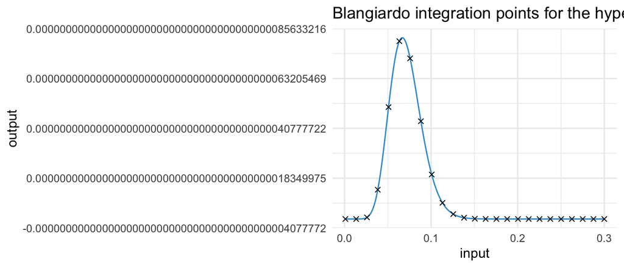

True posterior marginal of theta (blue line) overlaid with the choice of integration points. This naive grid places too many points in regions of the parameter space without much posterior density.

```r
ggplot(dense_theta) +
  geom_line(aes(x = input, y = output), col = midblue) +
  geom_point(data = blangiardo_theta, aes(x = input, y = output), shape = 4) +
  theme(axis.text.y=element_blank()) +
  labs(title = "Blangiardo integration points for the hyperparameters") +
  theme_minimal()
```

Optimisation on the log scale (to avoid constrained optimisation):

```r
its <- 1000
r_nlminb <- nlminb(start = 0,
                   objective = nl_post_marginal_theta,
                   log_input = TRUE,
                   control = list(iter.max = its, trace = 0))

r_optim <- optim(par = 0,
                 fn = nl_post_marginal_theta,
                 log_input = TRUE,
                 method = "Brent",
                 lower = -100, # Have to specify upper and lower bounds
                 upper = 100, # when using optimize (1D function)
                 control = list(maxit = its, trace = 0))

c(r_nlminb$par, r_optim$par) # The same
```

```
## [1] -2.640129 -2.640129
```

```r
r_opt <- r_nlminb
```

For INLA’s grid strategy, starting from the mode, we take steps of size $\delta_z$ checking that each point meets the criteria
$$\begin{equation}
\log \tilde p(\theta(0) \, | \, y) - \log \tilde p(\theta(z) \, | \,
y) < \delta_\pi. \label{eq:criteria}
\end{equation}$$
In the one dimensional case there is no need to do the $z$-parametrisation. Choosing $\delta_z$ and $\delta_\pi$ based upon manual tuning[^1]:

```r
delta_z <- 0.05
delta_pi <- 3
```

The following is very inefficient R programming but just an idea as to how it could be done:

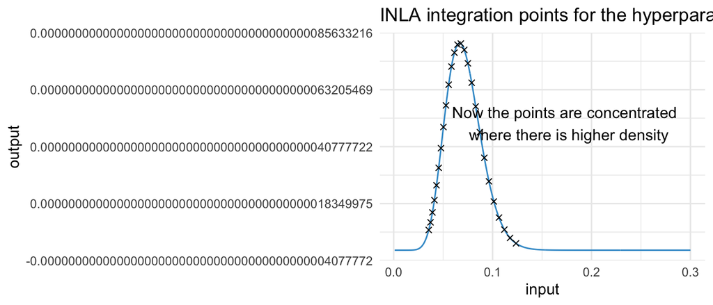

The INLA method grid points. This looks better but it still looks a little strange probably because of the reparametrisation. Then there is also the task of choosing the values of $\delta_z$ and $\delta_\pi$.

```r
# Increasing
points <- c(r_opt$par) # On the log theta scale

i <- 0
condition <- TRUE
while(condition) {
  i <- i + 1
  proposal <- r_opt$par + i * delta_z
  statistic <- nl_post_marginal_theta(theta = proposal, log_input = TRUE) -
               nl_post_marginal_theta(theta = r_opt$par, log_input = TRUE)
  condition <- (statistic < delta_pi)
  if(condition){
    points <- c(points, proposal)
  }
}

# Decreasing
i <- 0
condition <- TRUE
while(condition) {
  i <- i + 1
  proposal <- r_opt$par - i * delta_z
  statistic <- nl_post_marginal_theta(theta = proposal, log_input = TRUE) -
               nl_post_marginal_theta(theta = r_opt$par, log_input = TRUE)
  condition <- (statistic < delta_pi)
  if(condition){
    points <- c(points, proposal)
  }
}

inla_theta <- eval_grid(exp(points), f = post_marginal_theta)

ggplot(dense_theta) +
  geom_line(aes(x = input, y = output), col = midblue) +
  geom_point(data = inla_theta, aes(x = input, y = output), shape = 4) +
  theme(axis.text.y=element_blank()) +
  labs(title = "INLA integration points for the hyperparameters") +
  annotate(
    "text", x = 0.175, y = 5e-41,
    label = "Now the points are concentrated \n where there is higher density"
  ) +
  theme_minimal()
```

One of the INLA vignettes discusses how the user can set their own integration points – see `browseVignettes(package = "INLA")`. The integration points that `R-INLA` uses can be found using `fit$joint.hyper`, which we can add on to the above plot for interest:

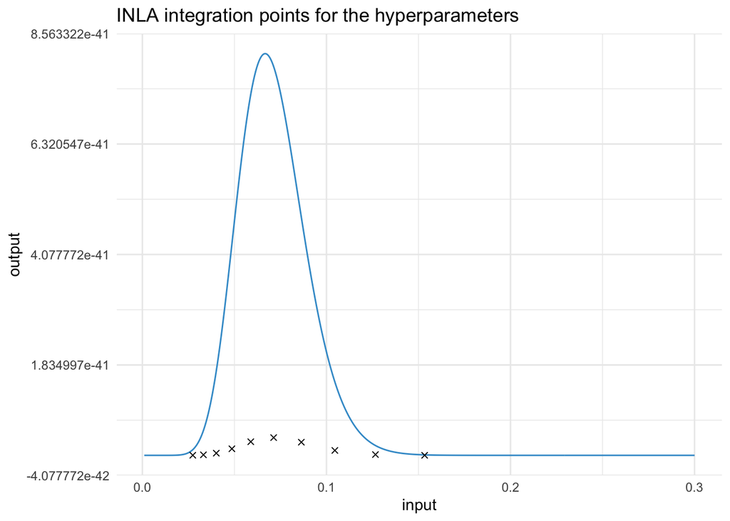

```r
internals_inla_theta <- data.frame(
  input = exp(fit$joint.hyper$`Log precision for the Gaussian observations`),
  output = exp(fit$joint.hyper$`Log posterior density`)
)

# Different normalising constant?
ggplot(dense_theta) +
  geom_line(aes(x = input, y = output), col = midblue) +
  geom_point(data = internals_inla_theta, aes(x = input, y = output), shape = 4) +
  theme(axis.text.y=element_blank()) +
  labs(title = "INLA integration points for the hyperparameters") +
  theme_minimal()
```

We take the set of points defined by `inla_theta` to be our $\{\theta^{(k)}\}$. $K$ is given by `length(points)` which equals 26.

Define a function `nl_joint_post` by taking the negative log of the joint posterior $p(x, \theta \, | \, y) = p(x \, | \, \theta, y) p(\theta \, | \, y)$ to give
$$\begin{equation}
- \log p(x, \theta \, | \, y) = - \log p(x \, | \, \theta, y) - \log
p(\theta \, | \, y).
\end{equation}$$

```r
nl_joint_post <- function(x, theta, log_input = FALSE) {
  nl_full_conditional_x(x, theta, log_input) +
  nl_post_marginal_theta(theta, log_input)
}
```

For any given input $x$ you can do quadrature according to
$$\begin{equation}
\tilde p(x \, | \, y) =
\sum_{k = 1}^K p(x \, | \, \theta^{(k)}, y) \times p(\theta^{(k)} \, |
\, y) \times \Delta^{(k)},
\end{equation}$$
but how should the range of $x$ be chosen? Blangiardo again use a naive grid for demonstration:

```r
blangiardo_x <- seq(-8, 5, length.out = 50)
```

Modify `nl_joint_post` to accept and return vectors using the base R function `Vectorize`, then apply the outer product:

```r
v_nl_joint_post <- Vectorize(nl_joint_post, vectorize.args = c("x", "theta"))
nl_joint_post <- outer(blangiardo_x, points, v_nl_joint_post, log_input = TRUE)
```

50 rows (the number of $x$ integration points) and 26 columns (the number of $\theta$ integration points):

```r
dim(nl_joint_post)
```

```
## [1] 50 26
```

The $x$ and $y$-axis do not correspond to values, just to indicies:

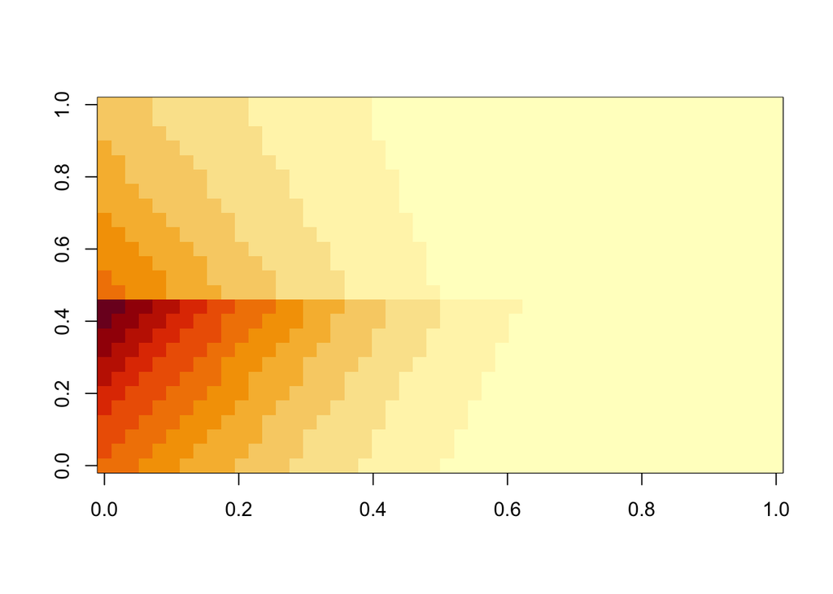

```r
image(nl_joint_post)
```

Following the book:

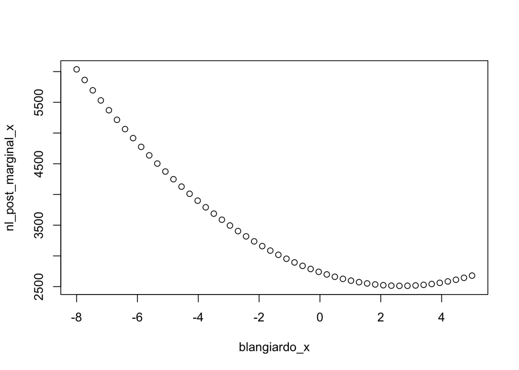

```r
nl_post_marginal_x <- rowSums(nl_joint_post)
plot(blangiardo_x, nl_post_marginal_x)
```

```r
blangiardo_x[[which.min(nl_post_marginal_x)]]
```

```
## [1] 2.612245
```

## Implementation in `TMB`

C++ for the negative log joint posterior is given by:

```cpp
// blangiardo.cpp

#include <TMB.hpp>

template <class Type>
Type objective_function<Type>::operator()()
{
  // Data block
  DATA_VECTOR(y);

  // Parameter block
  PARAMETER(x);
  PARAMETER(l_theta);

  // Transformed parameters block
  Type sigma = sqrt(1 / exp(l_theta));

  Type nll;
  nll = Type(0.0);

  // Priors
  nll -= dlgamma(l_theta, Type(1.6), Type(1 / 0.4), true);
  nll -= dnorm(x, Type(-3.0), Type(2.0), true);

  // Likelihood
  nll -= dnorm(y, x, sigma, true).sum();

  // ADREPORT
  ADREPORT(x)
  ADREPORT(sigma);

  return(nll);
}
```

```r
TMB::compile("blangiardo.cpp")
dyn.load(dynlib("blangiardo"))

param <- list(x = 0, l_theta = 0)
```

`h` with Laplace approximation is a function of $\dim(\theta)$ inputs, integrating out $x$ by specifying `random = c("x")`:

```r
h <- MakeADFun(
  data = dat,
  parameters = param,
  random = c("x"),
  DLL = "blangiardo",
  hessian = TRUE
)
```

```
## Constructing atomic D_lgamma
## Constructing atomic D_lgamma
```

`f` without Laplace approximation is a function of $\dim(\theta) + \dim(x)$ inputs:

```r
f <- MakeADFun(
  data = dat,
  parameters = param,
  DLL = "blangiardo",
  hessian = TRUE
)
```

Optimisation using `nlminb` and `optim` gets the same results:

```r
its <- 1000

tmb_nlminb <- nlminb(
  start = h$par,
  objective = h$fn,
  gradient = h$gr,
  control = list(iter.max = its, trace = 0)
)
```

[output not shown]

```r
tmb_optim <- optim(
  par = h$par,
  fn = h$fn,
  gr = h$gn,
  method = "Brent",
  lower = -100, # Have to specify upper and lower bounds
  upper = 100, # when using optimize (1D function)
  control = list(maxit = its, trace = 0)
)
```

[output not shown]

```r
c(tmb_optim$par, tmb_nlminb$par) # The same
```

```
##             l_theta
## -2.640129 -2.640129
```

```r
tmb_opt <- tmb_nlminb

sd_out <- sdreport(h, par.fixed = tmb_opt$par, getJointPrecision = TRUE)
```

```
## iter: 1  mgc: 0.0000000000000006661338
## outer mgc:  0.00000002666602
## iter: 1  value: 94.54446 mgc: 0.001420703 ustep: 1
## iter: 2  mgc: 0.0000000000000004440892
## outer mgc:  0.01536359
## iter: 1  value: 94.54536 mgc: 0.001419283 ustep: 1
## iter: 2  mgc: 0.0000000000000002220446
## outer mgc:  0.01534768
## outer mgc:  1.871831
```

The mode and comparison (I started by making the mistake of exponentiating `fit$summary.hyperpar$mode` rather than the internal version–on the log scale, as with R and `TMB`–which, because the transformation is non-linear, is not the same).

```r
#' For some reason the mode in the INLA result below is NA
kable_data <- data.frame(c(exp(fit$internal.summary.hyperpar$mean),
                           exp(r_opt$par),
                           exp(tmb_opt$par)))

rownames(kable_data) <- c("$\\texttt{R-INLA}$", "R", "$\\texttt{TMB}$")
colnames(kable_data) <- c("Posterior mode")

kableExtra::kable(kable_data, booktabs = TRUE, escape = FALSE, align = "c")
```

|  | Posterior mode |
| --- | --- |
| $\texttt{R-INLA}$ | 0.0690069 |
| R | 0.0713521 |
| $\texttt{TMB}$ | 0.0713521 |

Compare the variances for $\log(\theta)$:

```r
sd_out$cov.fixed # TMB
```

```
##            l_theta
## l_theta 0.06512266
```

```r
fit$internal.summary.hyperpar$sd^2 # INLA
```

```
## [1] 0.06652495
```

Compare $x$:

```r
sd_out$par.random # TMB
```

```
##        x
## 2.679973
```

```r
fit$summary.fixed # INLA
```

|  | mean | sd | 0.025quant | 0.5quant | 0.975quant | mode | kld |
| --- | --- | --- | --- | --- | --- | --- | --- |
| (Intercept) | 2.647905 | 0.6805103 | 1.257958 | 2.66514 | 3.940004 | NA | 0.00000004697001 |

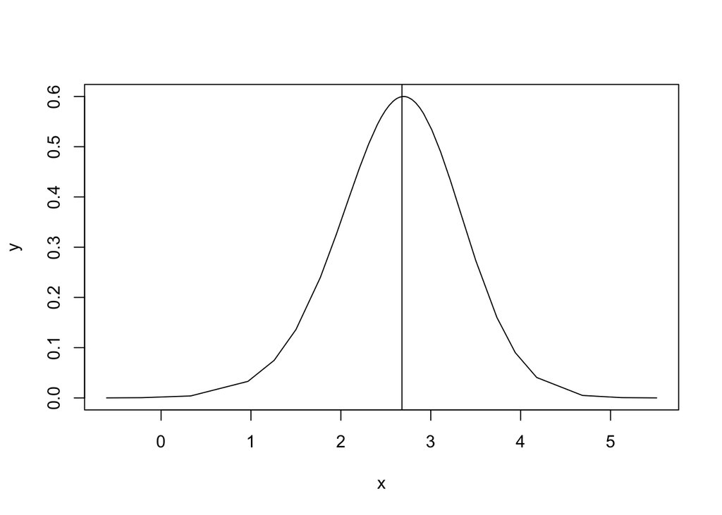

```r
plot(fit$marginals.fixed$`(Intercept)`, type = "l")
abline(v = sd_out$par.random)
```

# Example 2: Unknown

[^1]: It would be good to know how INLA selects these numbers in general